# Stat5405-Homework 4

Author

Damini Vadrevu

Published

October 1, 2023

## Due: Sun. Oct. 1 2023 at 11:59 pm - submit on HuskyCT

**Q1. (5 points).** Interpret this statement in your own words using a criterion you have studied: *The one-factor ANOVA* $F$-stat is very small, so that the chance of getting an $F$-statistic value which is as small or smaller than the $F$-stat obtained from the observed data is only $0.00004$.

The result from the one-factor ANOVA test indicates that it’s extremely rare to get the observed value of the F-statistic or a value even smaller than it. Specifically, there’s only a 0.004% chance of this happening if there’s no actual difference between the groups we’re studying. Given how rare this is, it suggests that there’s likely a significant difference between the groups we’re examining.

The F-statistic from the one-factor ANOVA test is notably low. This means that if there were no real difference between the groups we’re looking at, there’d be just a 0.004% chance of seeing such a small F-statistic or even lower. This tiny probability strongly suggests that the groups do indeed differ in some meaningful way.

**Q2. (45 points).** Consider the dataset tensile from the R package *ACSWR*. You looked at the one-factor ANOVA $F$-test in HW3. Now, use suitable R functions to answer these questions.

As the assumptions for this data have been satisfied in the previous homework, it is claimed to be of equal variances, normally distributed and independent.

```r
library(ACSWR)
library(carData)

data(tensile)
str(tensile)
```

```
'data.frame':   25 obs. of  4 variables:
 $ Test_Sequence   : int  1 2 3 4 5 6 7 8 9 10 ...
 $ Run_Number      : int  8 18 10 23 17 5 14 6 15 20 ...
 $ CWP             : int  20 30 20 35 30 15 25 20 25 30 ...
 $ Tensile_Strength: int  12 19 17 7 25 7 14 12 18 22 ...
```

```r
# Perform One-Factor ANOVA
model <- aov(Tensile_Strength ~ as.factor(CWP), data = tensile)
model
```

```
Call:
   aov(formula = Tensile_Strength ~ as.factor(CWP), data = tensile)

Terms:
                as.factor(CWP) Residuals
Sum of Squares          475.76    161.20
Deg. of Freedom              4        20

Residual standard error: 2.839014
Estimated effects may be unbalanced
```

```r
#checking normality of residuals
aovres <- residuals(model)
shapiro.test(aovres)
```

```
    Shapiro-Wilk normality test

data:  aovres
W = 0.94387, p-value = 0.1818
```

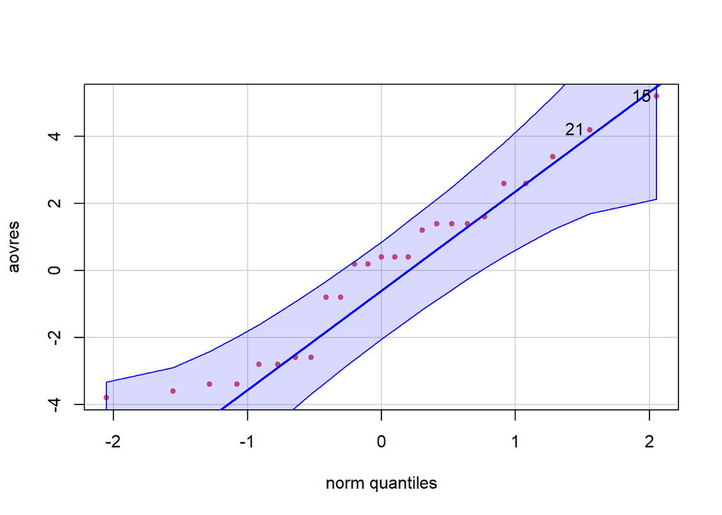

```
[1] 15 21
```

```r
car::qqPlot(aovres, main = NA, pch = 19, col = 2, cex = 0.7)
```

```r
# View the model summary
summary(model)
```

```
               Df Sum Sq Mean Sq F value   Pr(>F)
as.factor(CWP)  4  475.8  118.94   14.76 9.13e-06 ***
Residuals      20  161.2    8.06
---
Signif. codes:  0 '***' 0.001 '**' 0.01 '*' 0.05 '.' 0.1 ' ' 1
```

The p-value of the Shapiro test for the normality of residuals resulted in 0.1818 which is greater than the significance level of 0.05. Thus there is notenough evidence to reject the null hypothesis. This suggests that the residuals do not significantly deviate from a normal distribution.

From the qq-plot it can be observed that the residuals follow along the straight reference line and do not deviate from normality as much.

The F-value of 14.76 suggests that the variability between the group means (due to CWP levels) is much larger than the variability within the groups (residual error). Given the very small p-value (9.13e-06), we can reject the null hypothesis that all group means are equal. This means that the CWP levels have a significant effect on tensile strength.

To determine which specific CWP levels differ from each other in terms of mean tensile strength, you would need to conduct post-hoc pairwise comparisons (like the Bonferroni or Tukey tests)

#### 2(a)

#### Obtain solutions of the effects of the levels of *CWP* in the one-factor ANOVA model you fit for the response.

```r
model <- aov(Tensile_Strength ~ as.factor(CWP), data = tensile)
summary(lm(model))
```

```
Call:
lm(formula = model)

Residuals:
   Min     1Q Median     3Q    Max
  -3.8   -2.6    0.4    1.4    5.2

Coefficients:
                 Estimate Std. Error t value Pr(>|t|)
(Intercept)         9.800      1.270   7.719 2.02e-07 ***
as.factor(CWP)20    5.600      1.796   3.119 0.005409 **
as.factor(CWP)25    7.800      1.796   4.344 0.000315 ***
as.factor(CWP)30   11.800      1.796   6.572 2.11e-06 ***
as.factor(CWP)35    1.000      1.796   0.557 0.583753
---
Signif. codes:  0 '***' 0.001 '**' 0.01 '*' 0.05 '.' 0.1 ' ' 1

Residual standard error: 2.839 on 20 degrees of freedom
Multiple R-squared:  0.7469,    Adjusted R-squared:  0.6963
F-statistic: 14.76 on 4 and 20 DF,  p-value: 9.128e-06
```

Tensile_Strength of factor level 20, on average, is 5.6 units more than that of factor level 15.

Tensile_Strength of factor level 25, on average, is 7.8 units more than that of factor level 15.

Tensile_Strength of factor level 30, on average, is 11.8 units more than that of factor level 15.

Tensile_Strength of factor level 35, on average, is 1 unit more than that of factor level 15.

#### 2 (b)

#### Obtain point estimates, and 95% C.I. estimates of the true means $\mu_i$ of the five groups.

```r
#estimates of true means of five levels

pred.CWP <- expand.grid(CWP=unique(tensile$CWP))
lsmeans <- predict(model, newdata=pred.CWP, se=TRUE, interval="confidence")
cbind(pred.CWP, lsmeans$fit)
```

```
  CWP  fit       lwr      upr
1  20 15.4 12.751566 18.04843
2  30 21.6 18.951566 24.24843
3  35 10.8  8.151566 13.44843
4  15  9.8  7.151566 12.44843
5  25 17.6 14.951566 20.24843
```

*Interpretation:*

- CWP Level 20: The adjusted average tensile strength is 15.4. We are 95% confident that the true average tensile strength for this CWP level is between 12.75 and 18.05.
- CWP Level 30: The adjusted average tensile strength is 21.6. We are 95% confident that the true average tensile strength for this CWP level is between 18.95 and 24.25.
- CWP Level 35: The adjusted average tensile strength is 10.8. We are 95% confident that the true average tensile strength for this CWP level is between 8.15 and 13.45.
- CWP Level 15: The adjusted average tensile strength is 9.8. We are 95% confident that the true average tensile strength for this CWP level is between 7.15 and 12.45.
- CWP Level 25: The adjusted average tensile strength is 17.6. We are 95% confident that the true average tensile strength for this CWP level is between 14.95 and 20.25.

*Overall Interpretation:*

- The CWP level 30 has the highest adjusted average tensile strength, making it the strongest among the listed CWP levels based on this data. The CWP level 15 has the lowest adjusted average tensile strength.
- The width of C.I across different CWP levels are exactly 5.3 units, additionally supporting equal variance and suggesting consistent precision.

#### 2(c)

#### Use the Bonferroni multiple comparison procedures to conduct pairwise tests of equality of the group means. Interpret the results.

```r
pairwise.t.test(tensile$Tensile_Strength, tensile$CWP,
                p.adjust.method = "none")
```

```
    Pairwise comparisons using t tests with pooled SD

data:  tensile$Tensile_Strength and tensile$CWP

   15      20      25      30
20 0.00541 -       -       -
25 0.00031 0.23471 -       -
30 2.1e-06 0.00251 0.03754 -
35 0.58375 0.01859 0.00116 7.0e-06

P value adjustment method: none
```

```r
bonresult <- pairwise.t.test(tensile$Tensile, tensile$CWP, p.adjust.method = "bonferroni")
print(bonresult)
```

```
    Pairwise comparisons using t tests with pooled SD

data:  tensile$Tensile and tensile$CWP

   15      20     25     30
20 0.0541  -      -      -
25 0.0031  1.0000 -      -
30 2.1e-05 0.0251 0.3754 -
35 1.0000  0.1859 0.0116 7.0e-05

P value adjustment method: bonferroni
```

To find *which* pairs of means are different - requires testing equality of each of the $a(a-1)/2$ pairs. We can test each pair at the 5% level using the *pairwise.t.test()* function.

The matrix is fundamentally symmetrical. As a result, the intersection of row “15” and column “20” would have the same value as row “20” and column “15.” As a result, many values are denoted by a “-”.

*Interpreting the p-values:*

The pairs (15,35), (20,25), (20,35), (25,30), (15,20) are not significant.

#### 2(d)

#### Use the Tukey multiple comparison procedures to conduct pairwise tests of equality of the group means. Interpret the results.

```r
#assumptions for tukey

# Shapiro-Wilk test for normality
by(tensile$Tensile_Strength, tensile$CWP, shapiro.test)
```

```
tensile$CWP: 15

    Shapiro-Wilk normality test

data:  dd[x, ]
W = 0.88104, p-value = 0.314

------------------------------------------------------------
tensile$CWP: 20

    Shapiro-Wilk normality test

data:  dd[x, ]
W = 0.75383, p-value = 0.03228

------------------------------------------------------------
tensile$CWP: 25

    Shapiro-Wilk normality test

data:  dd[x, ]
W = 0.73872, p-value = 0.02332

------------------------------------------------------------
tensile$CWP: 30

    Shapiro-Wilk normality test

data:  dd[x, ]
W = 0.90202, p-value = 0.4211

------------------------------------------------------------
tensile$CWP: 35

    Shapiro-Wilk normality test

data:  dd[x, ]
W = 0.94197, p-value = 0.6799
```

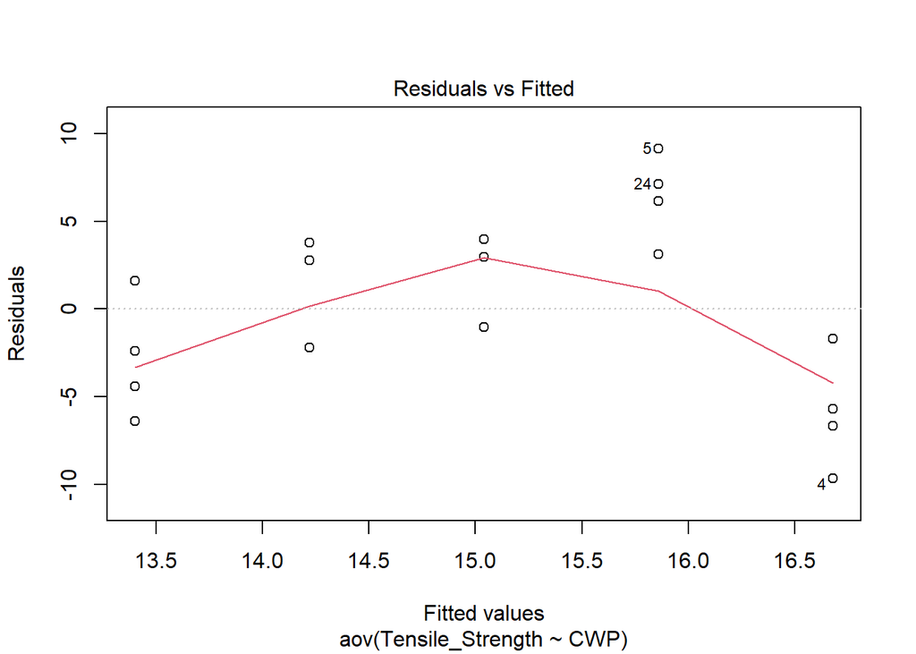

```r
#additivity and linearity
anova_model <- aov(Tensile_Strength ~ CWP, data=tensile)
plot(anova_model, 1)  # Residuals vs Fitted values
```

```r
#equal variances
library(car)
leveneTest(Tensile_Strength ~ as.factor(CWP), data=tensile)
```

```
Levene's Test for Homogeneity of Variance (center = median)
      Df F value Pr(>F)
group  4  0.3179 0.8626
      20
```

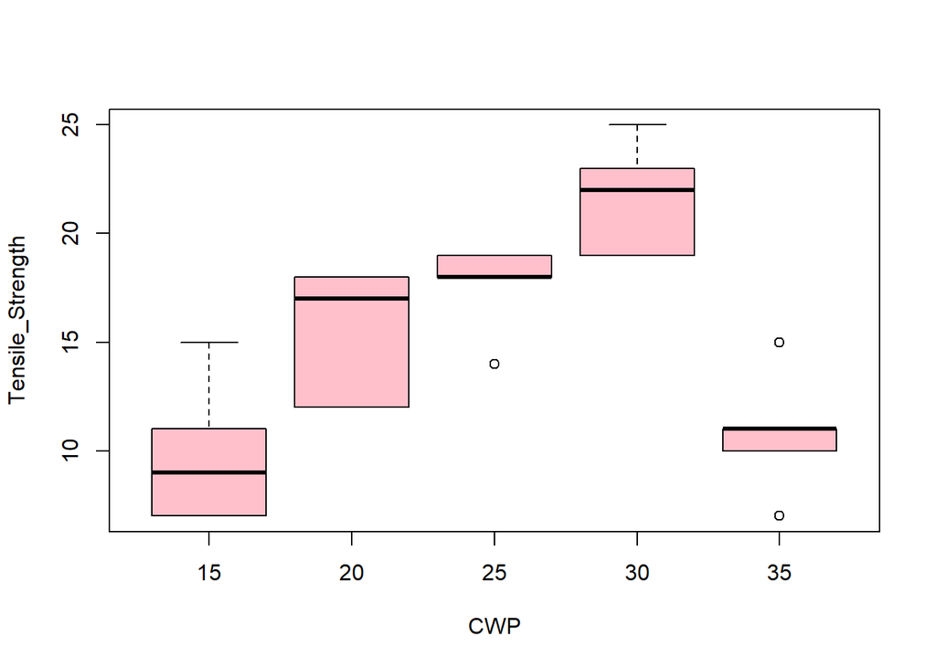

```r
#outliers
boxplot(Tensile_Strength ~ CWP, data=tensile, col="pink", border="black")
```

Even though some assumptions have not been met due to the presence of outliers and some levels of CWP not following a normal distribution, it is safe to proceed with the Tukey’s test based on the residual normality and since deviations from normality are not extreme. ANOVA and Tukey procedure are naturally robust and can handle minor deviations. The residual vs fitted plot even shows non-linearity as it appears to be following a curve.

```r
#pairwise comparisons Tukey's HSD test
TukeyHSD(model)
```

```
  Tukey multiple comparisons of means
    95% family-wise confidence level

Fit: aov(formula = Tensile_Strength ~ as.factor(CWP), data = tensile)

$`as.factor(CWP)`
       diff         lwr        upr     p adj
20-15   5.6   0.2270417 10.9729583 0.0385024
25-15   7.8   2.4270417 13.1729583 0.0025948
30-15  11.8   6.4270417 17.1729583 0.0000190
35-15   1.0  -4.3729583  6.3729583 0.9797709
25-20   2.2  -3.1729583  7.5729583 0.7372438
30-20   6.2   0.8270417 11.5729583 0.0188936
35-20  -4.6  -9.9729583  0.7729583 0.1162970
30-25   4.0  -1.3729583  9.3729583 0.2101089
35-25  -6.8 -12.1729583 -1.4270417 0.0090646
35-30 -10.8 -16.1729583 -5.4270417 0.0000624
```

- CWP Level 20 vs. Level 15: Tensile strength at level 20 is significantly higher than at level 15.
- CWP Level 25 vs. Level 15: Tensile strength at level 25 is significantly higher than at level 15.
- CWP Level 30 vs. Level 15: Tensile strength at level 30 is markedly higher than at level 15, with a notable difference in means.
- CWP Level 35 vs. Level 15: There is no statistically significant difference in tensile strength between levels 35 and 15.
- CWP Level 25 vs. Level 20: No significant difference in tensile strength is observed.
- CWP Level 30 vs. Level 20: Tensile strength at level 30 is significantly higher than at level 20.
- CWP Level 35 vs. Level 20: No significant difference in tensile strength is observed.
- CWP Level 30 vs. Level 25: No significant difference in tensile strength is observed between these levels.
- CWP Level 35 vs. Level 25: Tensile strength at level 35 is significantly lower than at level 25.
- CWP Level 35 vs. Level 30: Tensile strength at level 35 is significantly lower than at level 30.

To summarize, levels 25, 30, and 20 showed significant increases in tensile strength compared to level 15. Level 30 also had a significant increase over level 20. Levels 35 was found to have a significantly lower tensile strength than both levels 25 and 30.

e. Compute and interpret a suitable effect size to see whether the levels of *CWP* have a practically meaningful effect on tensile strength.

```r
library(sjstats)
library(effectsize)
anova_model <- aov(Tensile_Strength ~ as.factor(CWP), data=tensile)
eta_sq <- eta_squared(anova_model)
```

```
For one-way between subjects designs, partial eta squared is equivalent
  to eta squared. Returning eta squared.
```

```r
print(eta_sq)
```

```
# Effect Size for ANOVA

Parameter      | Eta2 |       95% CI
------------------------------------
as.factor(CWP) | 0.75 | [0.53, 1.00]

- One-sided CIs: upper bound fixed at [1.00].
```

The levels of CWP explain a substantial amount (75%) of the variability observed in tensile strength. This effect is statistically significant and practically meaningful, as reflected by the effect size and its confidence interval. Even at the lower end of the confidence interval (0.53), the effect of CWP levels on tensile strength is considered large.

**Q3. (50 points)** Consider the ToothGrowth dataset from the R package *datasets*. The response is *len*, the length of odontoblasts (cells responsible for tooth growth) in 60 guinea pigs. Each animal received one of three dose levels of vitamin C (0.5, 1, and 2 mg/day) denoted as the factor *dose* (Factor A) by one of two delivery methods, orange juice or ascorbic acid (a form of vitamin C and coded as VC), denoted as the factor *supp* (Factor B).

#### 3(a)

Fit and interpret a one-factor ANOVA model relating the response *len* to *dose* (Factor A).

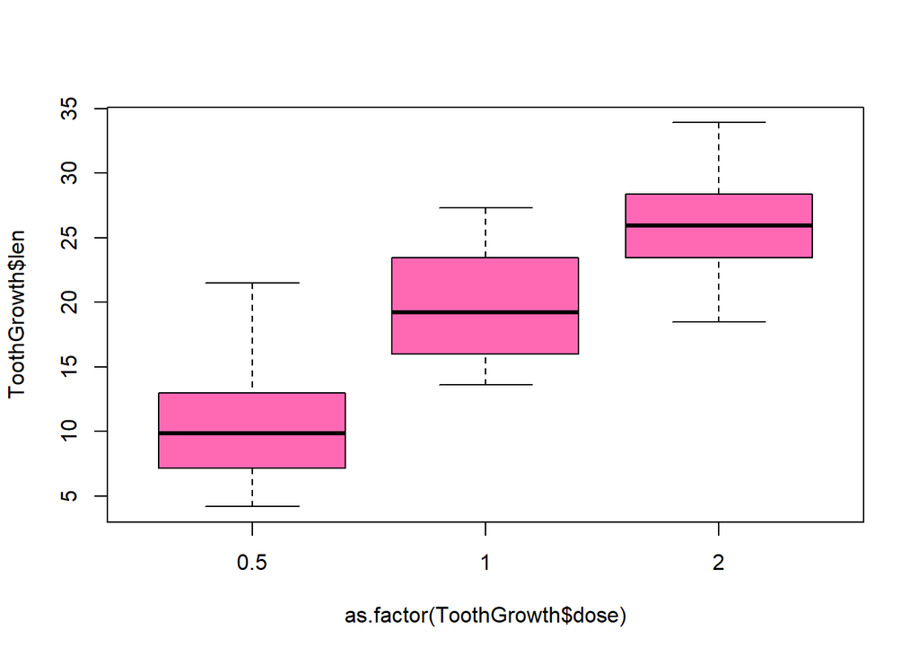

```r
#checking assumptions

#Normality
boxplot(ToothGrowth$len ~ as.factor(ToothGrowth$dose), col = "hotpink")
```

```r
shapiro.test(ToothGrowth$len)
```

```
    Shapiro-Wilk normality test

data:  ToothGrowth$len
W = 0.96743, p-value = 0.1091
```

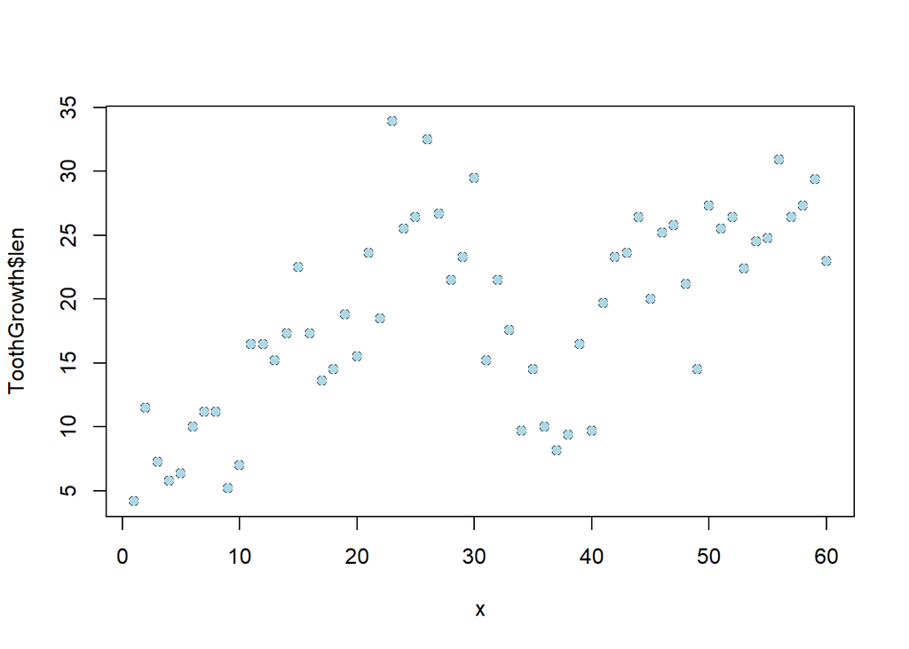

```r
#Independence
x <- 1:length(ToothGrowth$len)
plot(x, ToothGrowth$len)
points(x, ToothGrowth$len, pch = 16, col = "lightblue")
```

```r
data(ToothGrowth)
print(ToothGrowth)
```

```
    len supp dose
1   4.2   VC  0.5
2  11.5   VC  0.5
3   7.3   VC  0.5
4   5.8   VC  0.5
5   6.4   VC  0.5
6  10.0   VC  0.5
7  11.2   VC  0.5
8  11.2   VC  0.5
9   5.2   VC  0.5
10  7.0   VC  0.5
11 16.5   VC  1.0
12 16.5   VC  1.0
13 15.2   VC  1.0
14 17.3   VC  1.0
```

[output cut: 46 more lines]

```r
#checking for equal variances
levene_test <- leveneTest(len ~ factor(dose), data = ToothGrowth)
levene_test
```

```
Levene's Test for Homogeneity of Variance (center = median)
      Df F value Pr(>F)
group  2  0.6457 0.5281
      57
```

```r
# Fit the one-factor ANOVA model for dose
anova_dose <- aov(len ~ as.factor(dose), data = ToothGrowth)
summary(anova_dose)
```

```
                Df Sum Sq Mean Sq F value   Pr(>F)
as.factor(dose)  2   2426    1213   67.42 9.53e-16 ***
Residuals       57   1026      18
---
Signif. codes:  0 '***' 0.001 '**' 0.01 '*' 0.05 '.' 0.1 ' ' 1
```

```r
#checking normality of residuals
aovres <- residuals(anova_dose)
shapiro.test(aovres)
```

```
    Shapiro-Wilk normality test

data:  aovres
W = 0.96731, p-value = 0.1076
```

From the output above, it can be observed that the assumptions of normal residuals and equal variances have not been violated.

**Null Hypothesis** $H_0$ : The means of tooth growth are the same across all levels of vitamin C doses. In other words, the dose of vitamin C has no effect on tooth growth.

Mathematically: $\mu_1$ = $\mu_2$ = $\mu_3$

**Alternative Hypothesis** $H_a$ : At least one of the means of tooth growth across the different vitamin C dose levels is different.

> The result from the ANOVA indicates strong evidence against the null hypothesis and in favor of the alternative hypothesis. This means that there’s a significant difference in tooth growth across the different vitamin C dose levels.

#### 3.(b)

#### Fit and interpret a one-factor ANOVA model relating the response *len* to *supp* (Factor B).

```r
#checking for equal variances
levene_test <- leveneTest(len ~ factor(supp), data = ToothGrowth)
levene_test
```

```
Levene's Test for Homogeneity of Variance (center = median)
      Df F value Pr(>F)
group  1  1.2136 0.2752
      58
```

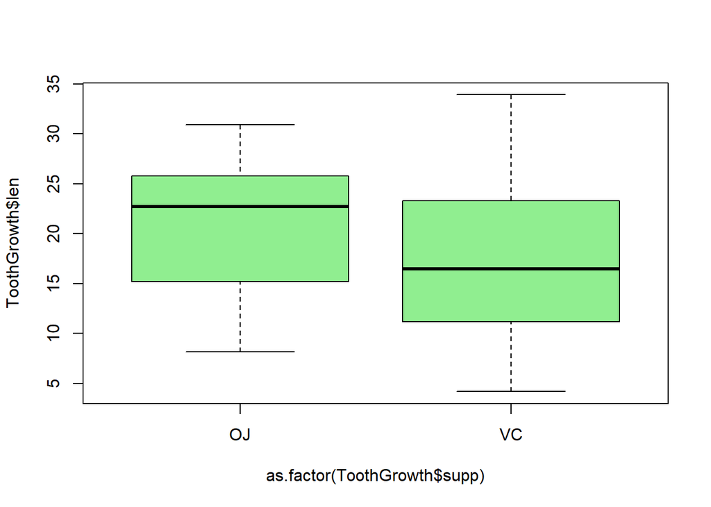

```r
#graphically
boxplot(ToothGrowth$len ~ as.factor(ToothGrowth$supp), col = "lightgreen")
```

```r
# Fit the one-factor ANOVA model for supp
anova_supp <- aov(len ~ as.factor(supp), data = ToothGrowth)
summary(anova_supp)
```

```
                Df Sum Sq Mean Sq F value Pr(>F)
as.factor(supp)  1    205  205.35   3.668 0.0604 .
Residuals       58   3247   55.98
---
Signif. codes:  0 '***' 0.001 '**' 0.01 '*' 0.05 '.' 0.1 ' ' 1
```

```r
#checking normality of residuals
aovres_s <- residuals(anova_supp)
t <- shapiro.test(aovres_s)
t
```

```
    Shapiro-Wilk normality test

data:  aovres_s
W = 0.96949, p-value = 0.1378
```

The assumptions of normal residuals and equal variances have been met.

**Null Hypothesis** $H_0$: The means of tooth growth are the same for both types of supplements. $\mu_{oj}$ = $\mu_{vc}$ Where:

- $\mu_{oj}$ is the mean tooth growth for the orange juice supplement.
- $\mu_{vc}$ is the mean tooth growth for the ascorbic acid (VC) supplement.

**Alternative Hypothesis** $H_1$: The means of tooth growth are not the same for the two types of supplements.

#### 3.(C)

Fit and interpret an additive two-factor ANOVA model relating the response *len* to *dose* (Factor A) and *supp* (Factor B).

```r
# Fitting the model
anova_two_factor <- aov(len ~ dose + supp, data=ToothGrowth)

# Displaying the summary
summary(anova_two_factor)
```

```
            Df Sum Sq Mean Sq F value   Pr(>F)
dose         1 2224.3  2224.3  123.99 6.31e-16 ***
supp         1  205.4   205.4   11.45   0.0013 **
Residuals   57 1022.6    17.9
---
Signif. codes:  0 '***' 0.001 '**' 0.01 '*' 0.05 '.' 0.1 ' ' 1
```

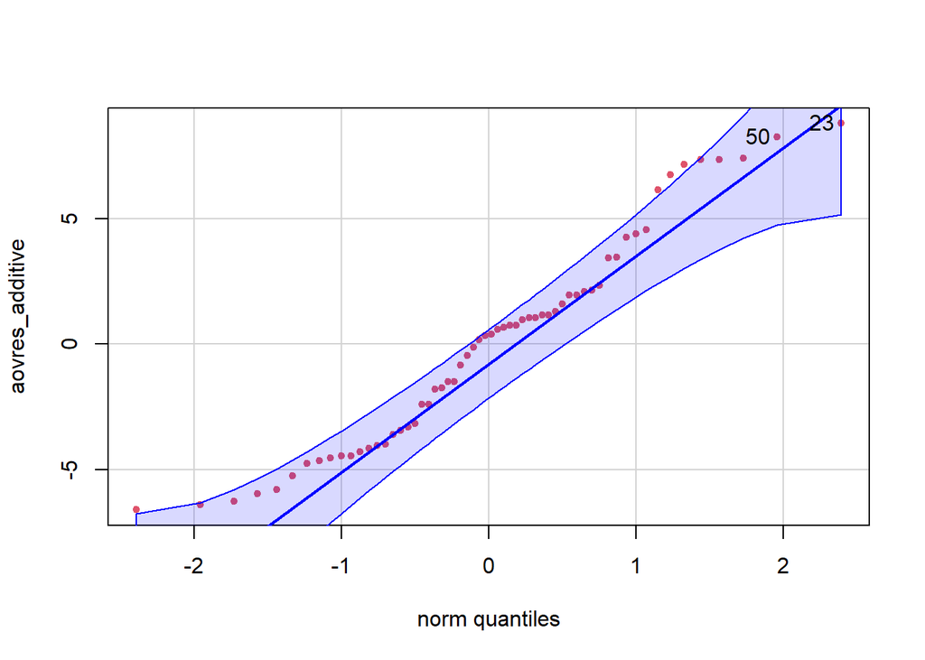

```
[1] 23 50
```

```r
aovres_additive <- residuals(anova_two_factor)
qqPlot(aovres_additive, main = NA, pch = 19, col = 2, cex = 0.7)
```

```r
shapiro.test(aovres_additive)
```

```
    Shapiro-Wilk normality test

data:  aovres_additive
W = 0.95538, p-value = 0.02809
```

**Null Hypothesis** $H_0$ : means of response variable len are the same across all levels for both the factors

**Alternative Hypothesis** $H_1$ : means of response variable len are not the same across all levels for both the factors

> Since the p-value is less than 0.05 for both the factors, we reject the null hypothesis and conclude that the means of the response variable (`len`) are not the same across all the levels for both the factors.

#### 3.(d)

Fit and interpret a two-factor ANOVA model with interaction relating the response *len* to *dose* (Factor A) and *supp* (Factor B).

```r
model_interaction <- aov(len ~ dose * supp, data = ToothGrowth)
summary(model_interaction)
```

```
            Df Sum Sq Mean Sq F value   Pr(>F)
dose         1 2224.3  2224.3 133.415  < 2e-16 ***
supp         1  205.4   205.4  12.317 0.000894 ***
dose:supp    1   88.9    88.9   5.333 0.024631 *
Residuals   56  933.6    16.7
---
Signif. codes:  0 '***' 0.001 '**' 0.01 '*' 0.05 '.' 0.1 ' ' 1
```

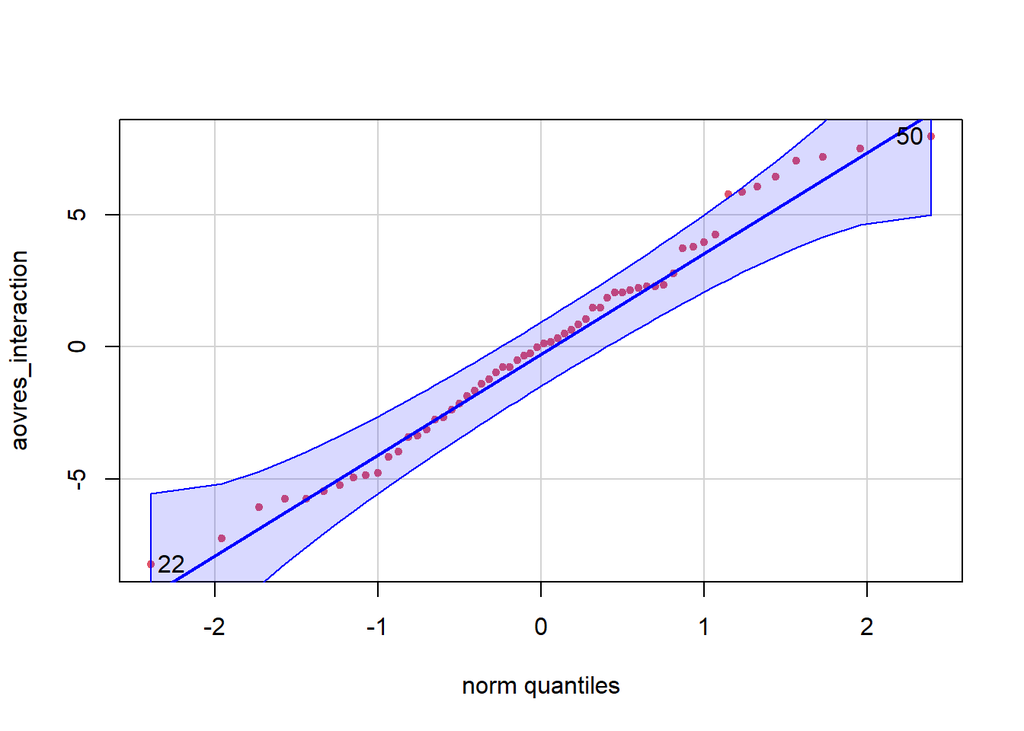

```
[1] 22 50
```

```r
aovres_interaction <- residuals(model_interaction)
qqPlot(aovres_interaction, main = NA, pch = 19, col = 2, cex = 0.7)
```

```r
shapiro.test(aovres_interaction)
```

```
    Shapiro-Wilk normality test

data:  aovres_interaction
W = 0.98162, p-value = 0.5008
```

Based on the p-value, residuals are normally distributed.

**Null Hypothesis (H0)**: There is no interaction effect between supp and doseon the outcome variable len This means that the effect of supp on len is the same at all levels of dose, and vice versa.

Formally, The effect of supp on len is independent of the level of dose.

**Alternative Hypothesis (Ha)**: There is an interaction effect between supp and dose on the outcome variable len. This means that the effect of supp on len differs depending on the level of dose, and vice versa.

Formally, The effect of sup on len depends on the level of dose

> As the p value is significantly small, it can be interpreted that there is an interaction effect between the two factors as we reject the null hypothesis.

#### 3.(e) Summarize what you learned from the analyses in (a) - (d).

##### SUMMARY

> *Effect of Vitamin C Dose on Tooth Growth*

> There is a statistically significant difference in tooth growth across the different doses of vitamin C. The extremely small p-value (9.53e-16) clearly indicates that the vitamin C dosage has a strong influence on tooth growth. The larger Mean Square value relative to the residuals suggests that different doses of vitamin C result in variations in tooth growth.

> *Effect of Supplement Type on Tooth Growth:*

> The p-value (0.0604) is slightly above the conventional 0.05 threshold for significance, suggesting a marginal effect of supplement type on tooth growth. This implies that the type of vitamin C delivery might have a suggestive influence on tooth growth, but the evidence isn’t strong enough to make a conclusive statement at the 5% significance level

> *Additive Model*

> Both factors - dose and supplement type - are statistically significant, with the dose having a more pronounced effect (p-value of 6.31e-16 for dose versus 0.0013 for supplement type). This suggests that while both factors influence tooth growth, the dosage of vitamin C has a stronger effect than the method of delivery.

> *Interaction between Dose and Supplement Type*

> There’s a statistically significant interaction between dose and supplement type (p-value of 0.024631). This means that the combined effect of dose and supplement type on tooth growth is not just the sum of their individual effects; they interact in a more complex manner. The presence of this interaction implies that the effect of one factor (like dosage) might differ depending on the level of the other factor (like supplement type).

##### KEY INSIGHTS:

- **Amount of Dose:** Regardless of other variables or conditions, every time the amount of vitamin C (dose) was analyzed in the studies, it showed a clear and strong influence on tooth growth. So, if you were only to change the dose while keeping everything else constant, you would observe significant changes in tooth growth.
- **Supplement Type’s Suggestive Influence:** When the type of vitamin C delivery was studied alone (in isolation), the evidence suggesting its effect on tooth growth was borderline (just slightly above the conventional threshold for statistical significance). However, when this supplement type was combined with the dose, it showed clearer evidence of having an impact. This suggests that while the method of vitamin C delivery does have an effect, it might not be as strong or consistent as the effect of the dosage itself.
- **Interaction:** The studies found that the combined effect of dose and supplement type on tooth growth is not simply the sum of their individual effects. They influence tooth growth in a way that’s more intricate, where the effect of one factor might change depending on the levels of the other. There is a need to consider both how much vitamin C to use (dosage) and how to deliver it (e.g., via orange juice or ascorbic acid), and understand that these two factors might influence outcomes differently when combined.

##### KEY TAKEAWAYS

1. **Dosage Influence:** The amount of vitamin C consistently and significantly impacts tooth growth.
2. **Delivery Method:** Its effect on growth is less conclusive when considered in isolation but is clearer when combined with dosage.
3. **Interaction Significance:** The combined effect of dose and delivery isn’t a simple sum; they jointly influence tooth growth in a complex manner. Both quantity and delivery method are essential considerations for understanding tooth development outcomes